# Exploratory Data Analysis on Happy Moments

Does hapiness mean different things to different people? If so, what might be the factors that affect people’s definitions of hapiness? And how?

Rui Zhang

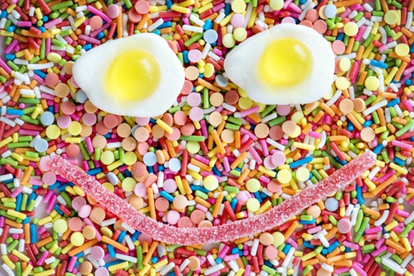

If you ask the people around you to describe the most unforgettable happy moments, you are very likely to be overwhelmed by the variety of their experiences. I’m highly inspired to advance the state of the art of understanding the causes of happiness. I will utilize exploratory data analysis to compare the patterns of happy causes across different subgroups of people to identify the factors that might influence people’s hapiness sources.

I will join the cleaned version of happy moments text file and demographic dataset to perform text mining and create data visualization to more intuitively compare the hapiness causes among different subgroups of people based on their demographic features.

# Do sources of hapiness vary across people in different age groups?

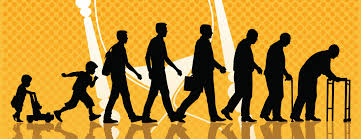

I divide the whole population into five groups based on their age: iGeneration(Teens & younger), Millennials(18 - 34 years old), Generation X(35 - 49 years old), Baby Boomers(50 - 69 years old) and Senior Citizen(70+ years older). Then I make a contingency table of age group and happy moments categories:

```r
Data_age <- merge(hm_data[,c("wid","predicted_category")],demographic[,c("wid","age")])
# join the processed happy moments dataset with age in demographic data
Data_age <- Data_age[order(Data_age$age),]
Data_age <- Data_age[grepl("[0-9]{1,2}", Data_age$age),] # remove rows with invalid values
Data_age$age <- as.numeric(Data_age$age)
Data_age$age_group[Data_age$age < 18] <-  "iGeneration"
Data_age$age_group[Data_age$age < 35 & Data_age$age >= 18] <- "Millennial"
Data_age$age_group[Data_age$age < 50 & Data_age$age >= 35] <- "Generation X"
Data_age$age_group[Data_age$age < 70 & Data_age$age >= 50] <- "Baby Boomers"
Data_age$age_group[Data_age$age >= 70] <- "Senior Citizen"
Data_age_split <- split(Data_age, Data_age$age_group)
categorycount <- function(df){
  affection        <- sum(df$predicted_category == "affection")
  achievement      <- sum(df$predicted_category == "achievement")
  bonding          <- sum(df$predicted_category == "bonding")
  enjoy_the_moment <- sum(df$predicted_category == "enjoy_the_moment")
  leisure          <- sum(df$predicted_category == "leisure")
  exercise         <- sum(df$predicted_category == "exercise")
  nature           <- sum(df$predicted_category == "nature")
  return(c(affection,achievement,bonding,enjoy_the_moment,leisure,exercise,nature))
}
age.summatrix <- sapply(Data_age_split, categorycount)
rownames(age.summatrix) <- c("affection","achievement","bonding",
                          "enjoy_the_moment","leisure","exercise","nature")
age.summatrix <- age.summatrix[,c("iGeneration","Millennial",
                                  "Generation X","Baby Boomers","Senior Citizen")]
age.summatrix
```

```
                 iGeneration Millennial Generation X Baby Boomers Senior Citizen
affection               4017      12622         9437         4446           3571
achievement             4941      13628         8606         3803           2884
bonding                 1825       4668         2527          945            753
enjoy_the_moment        1606       4575         2830         1166            916
leisure                  905       3474         1878          715            480
exercise                 177        562          275          112             69
nature                   163        580          487          282            329
```

Next, we conduct a chi-square test to check the correlation between age and what make people happy.

```r
chisq.test(age.summatrix)
```

```
    Pearson's Chi-squared test

data:  age.summatrix
X-squared = 1141.6, df = 24, p-value < 2.2e-16
```

We can see that the Chi-squared statistic is significant, which provides evidence that age does have an effect on the reasons why people feel happy. Then I explore the patterns of happiness categories among those age groups. I display the proportions of hapiness sources in the table below:

```r
categoryproportion <- function(df){
  affection        <- mean(df$predicted_category == "affection")
  achievement      <- mean(df$predicted_category == "achievement")
  bonding          <- mean(df$predicted_category == "bonding")
  enjoy_the_moment <- mean(df$predicted_category == "enjoy_the_moment")
  leisure          <- mean(df$predicted_category == "leisure")
  exercise         <- mean(df$predicted_category == "exercise")
  nature           <- mean(df$predicted_category == "nature")
  return(c(affection,achievement,bonding,enjoy_the_moment,leisure,exercise,nature))
}
age.propmatrix <- sapply(Data_age_split, categoryproportion)
rownames(age.propmatrix) <- c("affection","achievement","bonding",
                          "enjoy_the_moment","leisure","exercise","nature")
age.propmatrix <-
  age.propmatrix[,c("iGeneration","Millennial","Generation X",
                    "Baby Boomers","Senior Citizen")]
age.propmatrix
```

```
                 iGeneration Millennial Generation X Baby Boomers Senior Citizen
affection         0.29463107 0.31469246   0.36240399  0.387653675    0.396689625
achievement       0.36240282 0.33977412   0.33049155  0.331589502    0.320373250
bonding           0.13385654 0.11638286   0.09704301  0.082396024    0.083648078
enjoy_the_moment  0.11779375 0.11406418   0.10867896  0.101665359    0.101755166
leisure           0.06637817 0.08661398   0.07211982  0.062341965    0.053321484
exercise          0.01298225 0.01401182   0.01056068  0.009765455    0.007664963
nature            0.01195541 0.01446059   0.01870200  0.024588020    0.036547434
```

We can notice that the proportions of “affection” and “nature” slightly increase as people age while the proportions of “achievement” and “bonding” slightly decrease as people grow older. The reason might be that people tend to become more emotional when they age and their pace of life gets slower. So, they might gradually care less about their career and achievement and more about their beloved people. They also want to get closer to nature and experience a better environment. I further visualize the proportion pattern in the following heatmap:

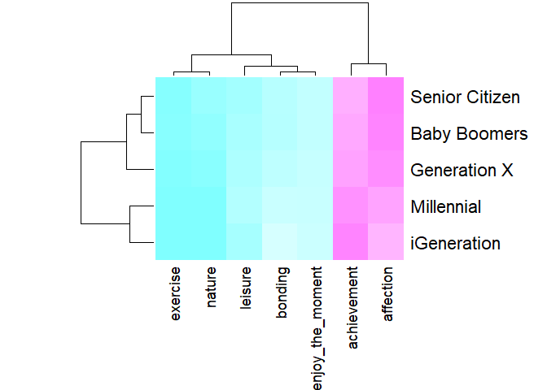

```r
age.heatmap <- heatmap(t(age.propmatrix),col = cm.colors(256), margins=c(10,5))
```

This changes of color depth in the above headmap more intuitively support my finding that people tend to switch from career/achievement to emotional needs as they age.

# Do the things that make men and women happy different?

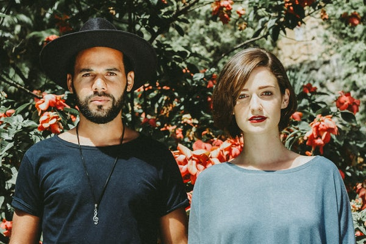

First I display a contingency table of gender and hapiness categories and perform the chi-square test to check the correlation between them:

```r
Data_gender <- merge(hm_data[,c("wid", "text", "predicted_category")],
                     demographic[,c("wid", "gender")])
Data_gender <- Data_gender[Data_gender$gender%in%c("f","m"),]
# join the processed happy moments dataset with gender in demographic data
Data_gender_split <- split(Data_gender, Data_gender$gender)
gender.summatrix <- sapply(Data_gender_split, categorycount)
gender.summatrix <- gender.summatrix[1:7,2:3]
rownames(gender.summatrix) <- c("affection","achievement","bonding",
                          "enjoy_the_moment","leisure","exercise","nature")
gender.summatrix
```

```
                     f     m
affection        17193 16744
achievement      12516 21110
bonding           4174  6454
enjoy_the_moment  4304  6703
leisure           2578  4824
exercise           365   820
nature             889   942
```

```r
chisq.test(gender.summatrix)
```

```
    Pearson's Chi-squared test

data:  gender.summatrix
X-squared = 1677, df = 6, p-value < 2.2e-16
```

The chi-squared statistic is 1677, which significantly demonstrates that the patterns of happiness sources for men and women are different. Next, I draw the word clouds to show the most high-frequency words in the cleaned version of happiness texts for both genders respectively.

```r
Data_gender_m <- Data_gender[Data_gender$gender == "m", ]
Data_gender_f <- Data_gender[Data_gender$gender == "f", ]
```

The word cloud for females is as follows:

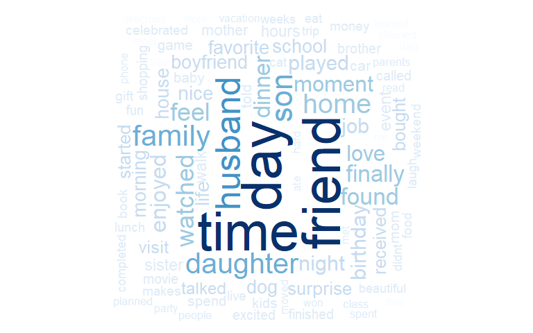

```r
ff.all <- Corpus(VectorSource(Data_gender_f$text))
tdm.all<-TermDocumentMatrix(ff.all)
tdm.tidy=tidy(tdm.all)
tdm.overall=summarise(group_by(tdm.tidy, term), sum(count))
wordcloud(tdm.overall$term, tdm.overall$`sum(count)`,
          scale=c(5,0.5),
          max.words=100,
          min.freq=1,
          random.order=FALSE,
          rot.per=0.3,
          use.r.layout=T,
          random.color=FALSE,
          colors=brewer.pal(9,"Blues"))
```

We can notice that many of the top high-frequency words have to do with family members, household chores or daily activities. The things that women care about most are usually associated with “affection”. This reflects the fact that women are more emotional and they need to express their feelings and relate to one another. Women more often choose family over work. One reality persists that women most often are the ones who adjust their schedules and make compromises when the needs of children and other family members collide with work.

The word cloud for males is as follows:

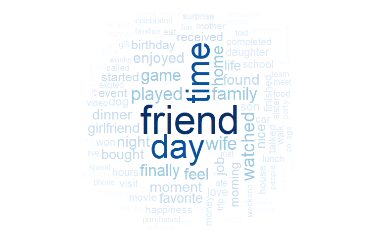

```r
ff.all <- Corpus(VectorSource(Data_gender_m$text))
tdm.all<-TermDocumentMatrix(ff.all)
tdm.tidy=tidy(tdm.all)
tdm.overall=summarise(group_by(tdm.tidy, term), sum(count))
wordcloud(tdm.overall$term, tdm.overall$`sum(count)`,
          scale=c(5,0.5),
          max.words=100,
          min.freq=1,
          random.order=FALSE,
          rot.per=0.3,
          use.r.layout=T,
          random.color=FALSE,
          colors=brewer.pal(9,"Blues"))
```

One thing we can notice from the word cloud is that men are more career-oriented than women. The happy moments key words regarding achievement in both job and school appear much more frequently than women. Another thing worth noting is that the hapiness sources of men are obviously more diverse than women. Besides affection and achievement, the things that can make men happy also include exercise, sports, game, video, party, etc. in their leisure time. Men seem to persue a rich, full and colorful life.

# Comparative Sentiment Analysis - Do people feel happy due to different reasons before and after they become parents?

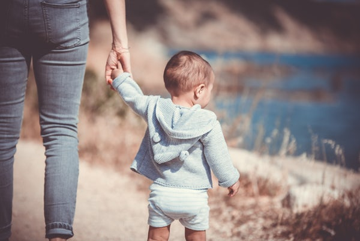

Next, I will perform comparative sentiment analysis on people who have already become parents and people who haven’t. I want to explore whether having children affect their sources of hapiness by their most common positive and negative words.

```r
Data_parenthood <- merge(demographic[,c("wid","parenthood")], hm_data[,c("wid","text")])
Data_parenthood <- Data_parenthood[,c("text","parenthood")]
```

The result of sentiment analysis for those parents are as follows:

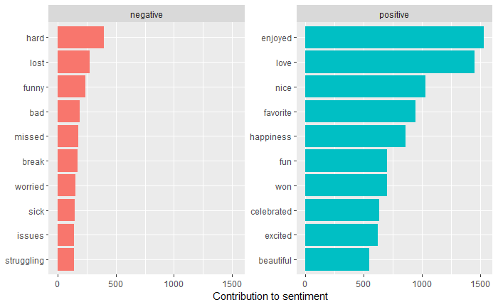

```r
tidy_parenthood <- Data_parenthood %>%
  filter(parenthood == "y") %>%
  unnest_tokens(word, text)
bing_word_counts <- tidy_parenthood %>%
  inner_join(get_sentiments("bing")) %>%
  count(word, sentiment, sort = TRUE) %>%
  ungroup()
bing_word_counts %>%
  group_by(sentiment) %>%
  top_n(10) %>%
  ungroup() %>%
  mutate(word = reorder(word, n)) %>%
  ggplot(aes(word, n, fill = sentiment)) +
  geom_col(show.legend = FALSE) +
  facet_wrap(~sentiment, scales = "free_y") +
  labs(y = "Contribution to sentiment",
       x = NULL) +
  coord_flip()
```

The result of sentiment analysis for those childless people is shown as below:

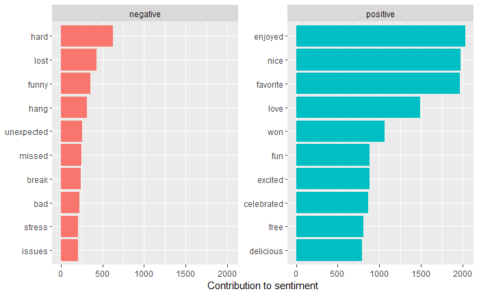

```r
tidy_parenthood <- Data_parenthood %>%
  filter(parenthood == "n") %>%
  unnest_tokens(word, text)
bing_word_counts <- tidy_parenthood %>%
  inner_join(get_sentiments("bing")) %>%
  count(word, sentiment, sort = TRUE) %>%
  ungroup()
bing_word_counts %>%
  group_by(sentiment) %>%
  top_n(10) %>%
  ungroup() %>%
  mutate(word = reorder(word, n)) %>%
  ggplot(aes(word, n, fill = sentiment)) +
  geom_col(show.legend = FALSE) +
  facet_wrap(~sentiment, scales = "free_y") +
  labs(y = "Contribution to sentiment",
       x = NULL) +
  coord_flip()
```

When we analyze the positive sentiments, we can find that childless people enjoy more personal pleasure and freedom because we can notice the words such as “free”, “delicious”, etc. contribute more to their positive sentiment while those people who become parents seem to enjoy more joint celebration or have some fun together. Some useful insights can also be obtained by analyzing the negative sentiments. Those childless people have more “unexpected” or “stress” moments while people suffer more “worried” or “struggling” moments after they become parents because they are concerned about their kids and they need to undertake more responsibilites of being a good parent. It is the process of overcoming the difficulties and fulfilling their responsibilities that gives those parents more hapiness. In short, parenthood changes the life style and mental status of people and thus highly affect people’s sources of hapiness.

# Are people’s happy moments also associated with their marital status?

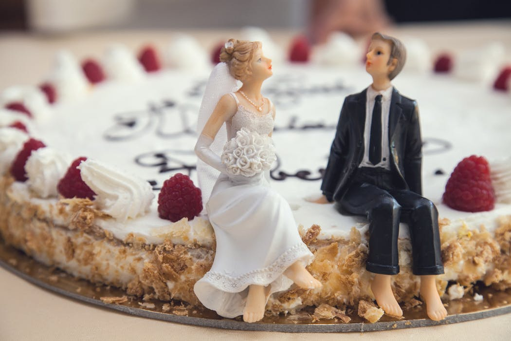

In this part, I want to introduce another method to perform comparative analysis for people in two marital status:married and single. Here I create bigrams to explore the correlations between words and visualize the network of bigrams. Then I can find the different patterns of the frequency or sentiments.

```r
Data_marital <- merge(hm_data[,c("wid","text")],demographic[,c("wid","marital")])
# join the processed happy moments dataset with country in demographic data
Data_marital <- Data_marital[Data_marital$marital%in%c("married","single"),
                             c("marital","text")]
# I only consider two marital status: married and single for simplicity
```

The bigram for married people’s happy moment words is as below:

```r
marital_bigrams <- Data_marital %>%
  filter(marital=="married") %>% # picking out records where marital status is married
  unnest_tokens(bigram, text, token = "ngrams", n = 2)
bigrams_separated <- marital_bigrams %>%
  separate(bigram, c("word1", "word2"), sep = " ")
bigrams_filtered <- bigrams_separated %>% # remove uninteresting stop words
  filter(!word1 %in% stop_words$word) %>%
  filter(!word2 %in% stop_words$word)
bigram_counts <- bigrams_filtered %>%
  count(word1, word2, sort = TRUE)
head(bigram_counts,15)
```

| word1 | word2 | n |
| --- | --- | --- |
| spend | time | 383 |
| moment | life | 294 |
| birthday | party | 236 |
| mother | day | 210 |
| watched | movie | 201 |
| ice | cream | 200 |
| video | game | 185 |
| makes | feel | 143 |
| spent | time | 132 |
| time | time | 125 |

[output cut: 5 more lines]

The network graph for married people’s happy moment words is as below:

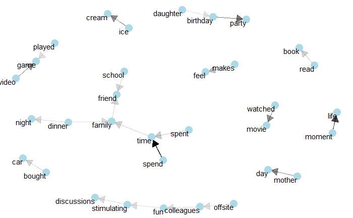

```r
bigram_graph <- bigram_counts %>%
  filter(n > 100) %>%
  graph_from_data_frame()
a <- grid::arrow(type = "closed", length = unit(.15, "inches"))
ggraph(bigram_graph, layout = "fr") +
  geom_edge_link(aes(edge_alpha = n), show.legend = FALSE,
                 arrow = a, end_cap = circle(.07, 'inches')) +
  geom_node_point(color = "lightblue", size = 5) +
  geom_node_text(aes(label = name), vjust = 1, hjust = 1) +
  theme_void()
```

The bigram for single people’s happy moment words is as below:

```r
marital_bigrams <- Data_marital %>%
  filter(marital=="single") %>% # picking out records where marital status is single
  unnest_tokens(bigram, text, token = "ngrams", n = 2)
bigrams_separated <- marital_bigrams %>%
  separate(bigram, c("word1", "word2"), sep = " ")
bigrams_filtered <- bigrams_separated %>% # remove uninteresting stop words
  filter(!word1 %in% stop_words$word) %>%
  filter(!word2 %in% stop_words$word)
bigram_counts <- bigrams_filtered %>%
  count(word1, word2, sort = TRUE)
head(bigram_counts,15)
```

| word1 | word2 | n |
| --- | --- | --- |
| video | game | 539 |
| spend | time | 395 |
| ice | cream | 309 |
| moment | life | 294 |
| watched | movie | 283 |
| birthday | party | 213 |
| friend | mine | 206 |
| mother | day | 206 |
| played | game | 198 |
| played | video | 198 |

[output cut: 5 more lines]

The network graph for single people’s happy moment words is as below:

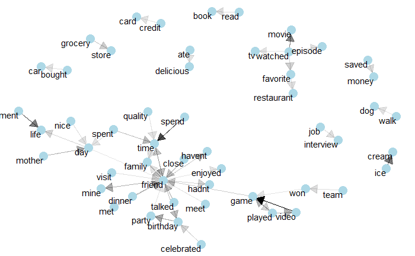

```r
bigram_graph <- bigram_counts %>%
  filter(n > 100) %>%
  graph_from_data_frame()
a <- grid::arrow(type = "closed", length = unit(.15, "inches"))
ggraph(bigram_graph, layout = "fr") +
  geom_edge_link(aes(edge_alpha = n), show.legend = FALSE,
                 arrow = a, end_cap = circle(.07, 'inches')) +
  geom_node_point(color = "lightblue", size = 5) +
  geom_node_text(aes(label = name), vjust = 1, hjust = 1) +
  theme_void()
```

# How do people around the world understand hapiness in different ways?

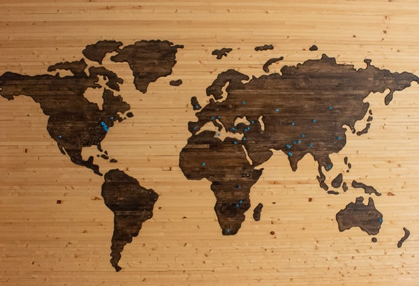

Here I plot global heatmaps for each hapiness category to display the geographic patterns of hapiness causes. This way I can explore whether country of residence impacts people’s hapiness notion.

```r
Data_country <- merge(hm_data[,c("wid","predicted_category")],demographic[,c("wid","country")])
# join the processed happy moments dataset with country in demographic data
Data_country <- Data_country[order(Data_country$country),]
Data_country <- Data_country[grepl("[A-Z]{3}", Data_country$country),]
# remove rows with invalid values
Data_country_split <- split(Data_country, Data_country$country)
country.prop.affection <- function(df){
  return(mean(df$predicted_category == "affection"))
}
prop.affection     <- sapply(Data_country_split, country.prop.affection)
prop.affection.df  <- data.frame(names(prop.affection), prop.affection)
rownames(prop.affection.df) <- NULL
prop.affection.df  <- prop.affection.df[-1,]
colnames(prop.affection.df) <- c("ISO3", "prop.affection")
sPDF <- joinCountryData2Map(prop.affection.df,
                            joinCode = "ISO3",
                            nameJoinColumn = "ISO3")
mapDevice() #create world map shaped window
mapCountryData(sPDF,nameColumnToPlot='prop.affection')
```

[output not shown]

```r
country.prop.achievement <- function(df){
  return(mean(df$predicted_category == "achievement"))
}
prop.achievement     <- sapply(Data_country_split, country.prop.achievement)
prop.achievement.df  <- data.frame(names(prop.achievement), prop.achievement)
rownames(prop.achievement.df) <- NULL
prop.achievement.df  <- prop.achievement.df[-1,]
colnames(prop.achievement.df) <- c("ISO3", "prop.achievement")
sPDF <- joinCountryData2Map(prop.achievement.df,
                            joinCode = "ISO3",
                            nameJoinColumn = "ISO3")
mapDevice() #create world map shaped window
mapCountryData(sPDF,nameColumnToPlot='prop.achievement')
```

[output not shown]

```r
country.prop.bonding <- function(df){
  return(mean(df$predicted_category == "bonding"))
}
prop.bonding     <- sapply(Data_country_split, country.prop.bonding)
prop.bonding.df  <- data.frame(names(prop.bonding), prop.bonding)
rownames(prop.bonding.df) <- NULL
prop.bonding.df  <- prop.bonding.df[-1,]
colnames(prop.bonding.df) <- c("ISO3", "prop.bonding")
sPDF <- joinCountryData2Map(prop.bonding.df,
                            joinCode = "ISO3",
                            nameJoinColumn = "ISO3")
mapDevice() #create world map shaped window
mapCountryData(sPDF,nameColumnToPlot='prop.bonding')
```

[output not shown]

```r
country.prop.enjoy_the_moment <- function(df){
  return(mean(df$predicted_category == "enjoy_the_moment"))
}
prop.enjoy_the_moment     <- sapply(Data_country_split, country.prop.enjoy_the_moment)
prop.enjoy_the_moment.df  <- data.frame(names(prop.enjoy_the_moment),
                                        prop.enjoy_the_moment)
rownames(prop.enjoy_the_moment.df) <- NULL
prop.enjoy_the_moment.df  <- prop.enjoy_the_moment.df[-1,]
colnames(prop.enjoy_the_moment.df) <- c("ISO3", "prop.enjoy_the_moment")
sPDF <- joinCountryData2Map(prop.enjoy_the_moment.df,
                            joinCode = "ISO3",
                            nameJoinColumn = "ISO3")
mapDevice() #create world map shaped window
mapCountryData(sPDF,nameColumnToPlot='prop.enjoy_the_moment')
```

[output not shown]

```r
country.prop.exercise <- function(df){
  return(mean(df$predicted_category == "exercise"))
}
prop.exercise     <- sapply(Data_country_split, country.prop.exercise)
prop.exercise.df  <- data.frame(names(prop.exercise), prop.exercise)
rownames(prop.exercise.df) <- NULL
prop.exercise.df  <- prop.exercise.df[-1,]
colnames(prop.exercise.df) <- c("ISO3", "prop.exercise")
sPDF <- joinCountryData2Map(prop.exercise.df,
                            joinCode = "ISO3",
                            nameJoinColumn = "ISO3")
mapDevice() #create world map shaped window
mapCountryData(sPDF,nameColumnToPlot='prop.exercise')
```

[output not shown]

```r
country.prop.leisure <- function(df){
  return(mean(df$predicted_category == "leisure"))
}
prop.leisure     <- sapply(Data_country_split, country.prop.leisure)
prop.leisure.df  <- data.frame(names(prop.leisure), prop.leisure)
rownames(prop.leisure.df) <- NULL
prop.leisure.df  <- prop.leisure.df[-1,]
colnames(prop.leisure.df) <- c("ISO3", "prop.leisure")
sPDF <- joinCountryData2Map(prop.leisure.df,
                            joinCode = "ISO3",
                            nameJoinColumn = "ISO3")
mapDevice() #create world map shaped window
mapCountryData(sPDF,nameColumnToPlot='prop.leisure')
```

[output not shown]

```r
country.prop.nature <- function(df){
  return(mean(df$predicted_category == "nature"))
}
prop.nature     <- sapply(Data_country_split, country.prop.nature)
prop.nature.df  <- data.frame(names(prop.nature), prop.nature)
rownames(prop.nature.df) <- NULL
prop.nature.df  <- prop.nature.df[-1,]
colnames(prop.nature.df) <- c("ISO3", "prop.nature")
sPDF <- joinCountryData2Map(prop.nature.df,
                            joinCode = "ISO3",
                            nameJoinColumn = "ISO3")
mapDevice() #create world map shaped window
mapCountryData(sPDF,nameColumnToPlot='prop.nature')
```

[output not shown]

# References

1. Natural Language Processing: from [Tutorial](https://github.com/TZstatsADS/ADS_Teaching/blob/master/Projects_StarterCodes/Project1-RNotebook/doc/Text_Processing.Rmd)
2. Text Mining: from [Topic Modelling](https://www.tidytextmining.com/topicmodeling.html#latent-dirichlet-allocation)